# Time Series Analysis of Turkish Economic Indicators

In this report, I embark on a comprehensive time series analysis, utilizing data sourced from the Electronic Data Delivery System of Turkey. My investigation spans a decade, covering the period from January 2014 to January 2024, with a monthly data frequency. This analysis is pivotal for understanding trends within key economic indicators that influence and reflect the state of Turkey's economy.

## Selection of Time Series

For a nuanced analysis, I've selected three distinct time series, each representing a different facet of the Turkish economy:

1. **Total Number of Houses Sold**: This series encapsulates the real estate dynamics, offering insights into the housing market trends over the last ten years.
2. **Workforce Numbers**: Representing the labor market, this series provides a window into employment trends, workforce expansions, or contractions, which are crucial for assessing economic health.
3. **Tractor Production Numbers**: As a measure of agricultural and industrial activity, the production of tractors serves as an indicator of both sectors' vitality, reflecting broader economic conditions.

### Preliminary Selection Process

An essential step in my analysis involved evaluating a broad spectrum of time series data. Guided by a specific instruction, I adopted a rigorous selection criterion based on the correlation coefficient between each pair of series. My goal was to select datasets with a correlation of less than 0.5. This constraint was strategically applied to ensure that the series chosen offer a diverse and non-redundant representation of Turkey's economy. By prioritizing time series with minimal correlation, I aimed to encompass a wider array of economic indicators, thereby enhancing the breadth and depth of my analysis.

The decision to focus on series with low correlation serves a dual purpose. First, it minimizes the overlap in the information each series provides, ensuring that the analysis captures a broad spectrum of economic activities. Second, it allows for a more nuanced exploration of independent trends and patterns within different sectors of the economy. Such an approach is instrumental in achieving a comprehensive understanding of the economic landscape in Turkey.

Through my detailed analysis, I am determined to uncover significant underlying trends, identify cyclic patterns, and develop potential forecasts that shed light on Turkey's economic future. The insights derived from this study are intended to offer valuable perspectives for policymakers, economists, and various stakeholders. By carefully selecting and examining these time series, I contribute to a deeper understanding of the dynamics at play in Turkey's economy, with the ultimate goal of informing effective decision-making and policy formulation.

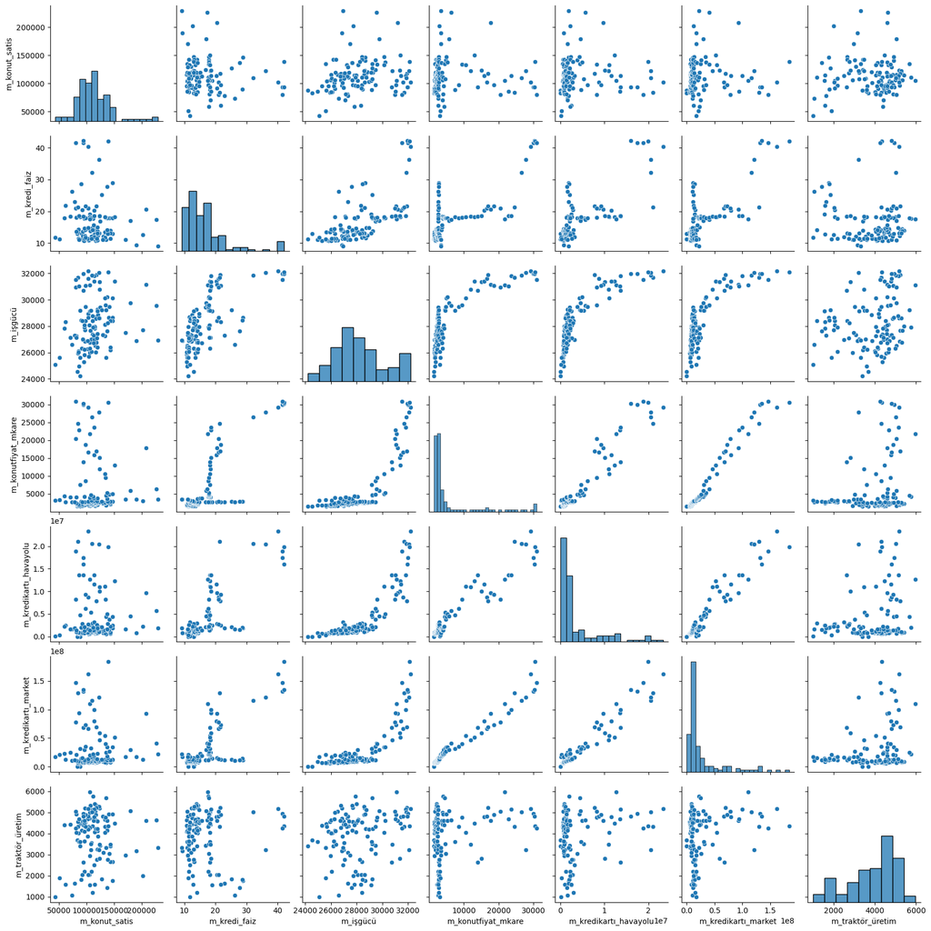

```
                       m_konut_satis  m_kredi_faiz  m_işgücü  \
m_konut_satis               1.000000     -0.104725  0.187703
m_kredi_faiz               -0.104725      1.000000  0.672797
m_işgücü                    0.187703      0.672797  1.000000
m_konutfiyat_mkare         -0.026889      0.775422  0.807819
m_kredikartı_havayolu       0.020390      0.763232  0.833134
m_kredikartı_market         0.006260      0.786493  0.794198
m_traktör_üretim          0.044794     -0.001230  0.225341

                       m_konutfiyat_mkare  m_kredikartı_havayolu  \
m_konut_satis                   -0.026889               0.020390
m_kredi_faiz                     0.775422               0.763232
m_işgücü                         0.807819               0.833134
m_konutfiyat_mkare               1.000000               0.961319
m_kredikartı_havayolu            0.961319               1.000000
m_kredikartı_market              0.983312               0.962495
m_traktör_üretim               0.268081               0.207102

                       m_kredikartı_market  m_traktör_üretim
m_konut_satis                     0.006260            0.044794
m_kredi_faiz                      0.786493           -0.001230
m_işgücü                          0.794198            0.225341
m_konutfiyat_mkare                0.983312            0.268081
m_kredikartı_havayolu             0.962495            0.207102
m_kredikartı_market               1.000000            0.261130
m_traktör_üretim                0.261130            1.000000
```

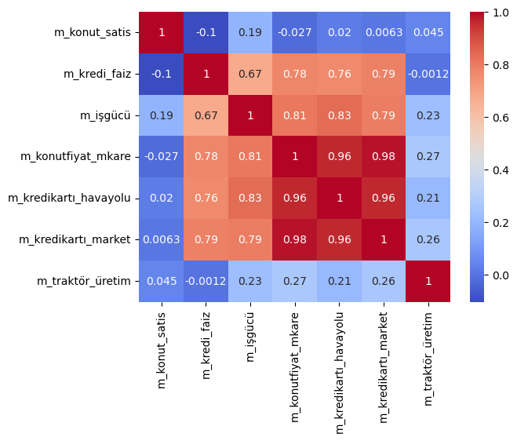

```python
import pandas as pd
import matplotlib.pyplot as plt
import seaborn as sns
import matplotlib.pyplot as plt

def read_and_index(file_path):
    df = pd.read_excel(file_path, parse_dates=['Tarih'])
    df.set_index('Tarih', inplace=True)
    return df

df1 = read_and_index('./ie360_hw1/m_konut_satis.xlsx')
df2 = read_and_index('./ie360_hw1/m_kredi_faiz.xlsx')
df3 = read_and_index('./ie360_hw1/m_işgücü.xlsx')
df4 = read_and_index('./ie360_hw1/m_konutfiyat_mkare.xlsx')
df5 = read_and_index('./ie360_hw1/m_kredikartı_havayolu.xlsx')
df6 = read_and_index('./ie360_hw1/m_kredikartı_market.xlsx')
df7 = read_and_index('./ie360_hw1/m_traktör_üretim.xlsx')

file_path = './ie360_hw1/m_işgücü.xlsx'
df_workforce = pd.read_excel(file_path, index_col='Tarih', parse_dates=True)

# Sequentially merge the data frames on the 'Tarih' (Date) index
dfs = [df1,df2,df3,df4,df5,df6,df7]
df_merged = dfs[0]
for df in dfs[1:]:
    df_merged = df_merged.merge(df, left_index=True, right_index=True, how='inner')

# Visualize the data
sns.pairplot(df_merged)
plt.show()

# Compute the correlation matrix
corr_matrix = df_merged.corr()

# Print the correlation matrix
print(corr_matrix)

# Visualize the correlation matrix
sns.heatmap(corr_matrix, annot=True, cmap='coolwarm')
plt.show()
```

## Analysis of Workforce Time Series

### Initial Exploration

My analysis commenced with an in-depth exploration of the workforce time series. This phase is crucial for establishing a foundational understanding of the data's characteristics and behavior over time.

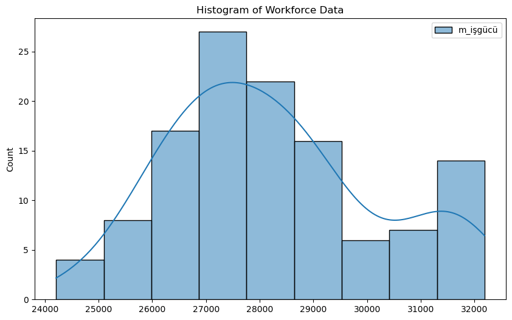

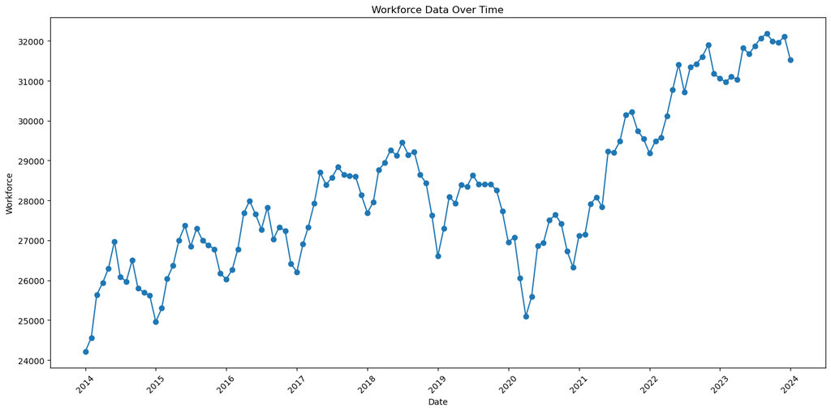

```python
plt.figure(figsize=(10, 6))
sns.histplot(data=df_workforce, kde=True)
plt.title('Histogram of Workforce Data')
plt.show()
plt.figure(figsize=(14, 7))
plt.plot(df_workforce.index, df_workforce['m_işgücü'], marker='o', linestyle='-')
plt.title('Workforce Data Over Time')
plt.xlabel('Date')
plt.ylabel('Workforce')
plt.xticks(rotation=45)
plt.tight_layout()
plt.show()
```

#### 1. **Histogram Analysis**

The histogram on the top displays the distribution of the workforce data points over the selected time period. The x-axis represents the number of people in the workforce, categorized into bins, while the y-axis represents the count of months that fall into each bin. The distribution appears to be roughly bell-shaped but shows some asymmetry, suggesting a slight skewness in the number of months with higher workforce counts. Notably, there's a higher frequency of months where the workforce size is around 27,000 to 28,000. The distribution's shape provides an initial understanding of the central tendency and variability of the data.

### 2. **Time Series Plot**

The line graph on the bottom plots the workforce size on the y-axis against time on the x-axis, with each point representing the workforce size for a given month. This plot reveals several important characteristics:

#### Trend:

There appears to be an overall increasing trend in the workforce numbers over the ten-year period, indicating a growing labor market in Turkey.

#### Seasonality :

The plot shows a pattern of fluctuations that seems to repeat at regular intervals, suggesting seasonal variations in the workforce size, which could be related to agricultural cycles, tourism, or other seasonal industries.

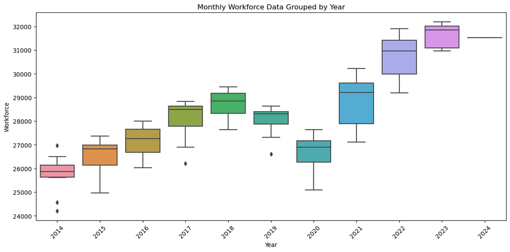

```python
df1 = pd.read_excel('./ie360_hw1/m_işgücü.xlsx', parse_dates=['Tarih'])

df1['Year'] = df1['Tarih'].dt.year

fig, ax = plt.subplots(figsize=(12, 6))

# Plot df1
sns.boxplot(ax=ax, x='Year', y='m_işgücü', data=df1)
ax.set_title('Monthly Workforce Data Grouped by Year')
ax.set_ylabel('Workforce')
ax.set_xlabel('Year')

ax.set_xticklabels(ax.get_xticklabels(), rotation=45)

plt.tight_layout()
plt.show()
```

## Box Plot Analysis of Monthly Workforce Data Grouped by Year

The box plot visualizes the distribution of monthly workforce data across different years, providing a clear summary of the central tendency, dispersion, and skewness of the data on a year-by-year basis.

Each box in the plot represents one year's worth of workforce data:

- **Median (Central Line)**: The line in the middle of each box indicates the median workforce size for that year, giving a sense of the central trend without the influence of outliers.
- **Interquartile Range (Box Length)**: The length of each box shows the interquartile range (IQR), which is the spread between the 25th percentile (Q1) and the 75th percentile (Q3). A larger box suggests more variability in monthly workforce data.
- **Whiskers**: The lines extending from the top and bottom of each box show the range of the data, excluding outliers. They typically extend to 1.5 * IQR above and below the box.
- **Outliers (Diamonds)**: Points that fall outside of the whiskers are plotted individually, indicating months that had unusually high or low workforce numbers.

From this plot, we can observe the following:

- **Yearly Trends**: There is an upward movement in the median over the years, which corroborates the increasing trend observed in the line graph.
- **Variability**: The varying box lengths suggest that some years experienced more month-to-month fluctuations in the workforce size than others.
- **Outliers**: The presence of outliers in certain years could indicate atypical events or changes in economic conditions affecting the workforce numbers.

This box plot serves as an effective tool for year-over-year comparison, revealing changes in the labor market's dynamics that might not be evident from a time series plot alone.

## Correlation Analysis with Google Trends Data

To enhance the modeling of the workforce time series, I investigated potential correlations with relevant search terms from Google Trends. The keywords examined were reflective of labor market conditions, including "uzaktan eğitim" (distance learning), "uzaktan çalışma" (remote work), "işsizlik maaşı" (unemployment benefit), "iş ilanları" (job postings), "iş görüşmesi" (job interview), and "cv hazırlama" (CV preparation).

The search frequency of these terms can act as proxy indicators for economic activity and labor market trends. I began by retrieving the search trend data for these keywords and then computed the correlation coefficients between these trends and the workforce data to identify any statistically significant relationships.

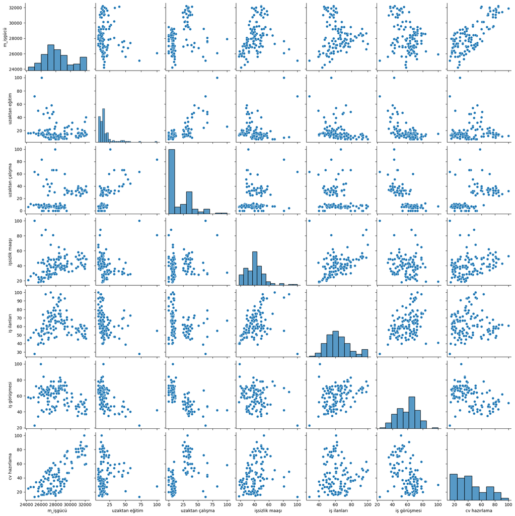

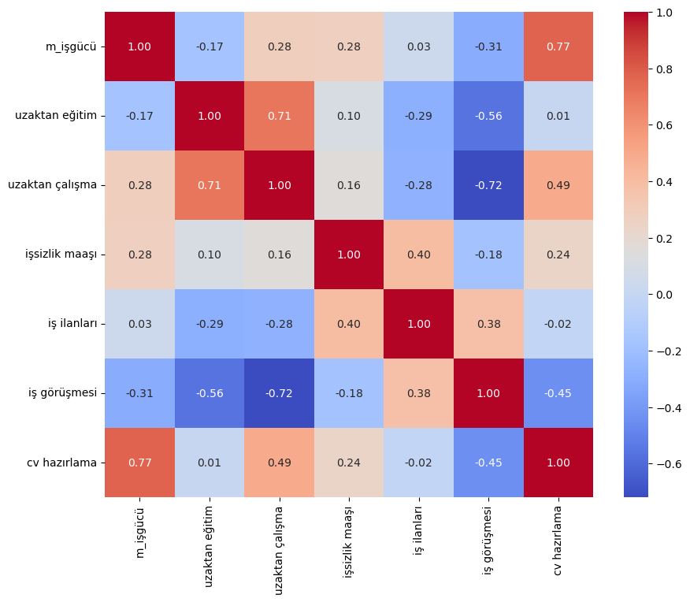

```python
workforce_data = pd.read_excel('./ie360_hw1/m_işgücü.xlsx', parse_dates=['Tarih'])
workforce_data.set_index('Tarih', inplace=True)

search_volume_kw1 = pd.read_csv('./ie360_hw1/gt_uzaktaneğitim.csv', header=1)
search_volume_kw1.columns = ['Tarih', 'uzaktan eğitim']
search_volume_kw1['Tarih'] = pd.to_datetime(search_volume_kw1['Tarih'])
search_volume_kw1.set_index('Tarih', inplace=True)

search_volume_kw2 = pd.read_csv('./ie360_hw1/gt_uzaktançalışma.csv', header=1)
search_volume_kw2.columns = ['Tarih', 'uzaktan çalışma']
search_volume_kw2['Tarih'] = pd.to_datetime(search_volume_kw2['Tarih'])
search_volume_kw2.set_index('Tarih', inplace=True)

search_volume_kw3 = pd.read_csv('./ie360_hw1/gt_işsizlikmaaşı.csv', header=1)
search_volume_kw3.columns = ['Tarih', 'işsizlik maaşı']
search_volume_kw3['Tarih'] = pd.to_datetime(search_volume_kw3['Tarih'])
search_volume_kw3.set_index('Tarih', inplace=True)

search_volume_kw4 = pd.read_csv('./ie360_hw1/gt_işlanları.csv', header=1)
search_volume_kw4.columns = ['Tarih', 'iş ilanları']
search_volume_kw4['Tarih'] = pd.to_datetime(search_volume_kw4['Tarih'])
search_volume_kw4.set_index('Tarih', inplace=True)

search_volume_kw5 = pd.read_csv('./ie360_hw1/gt_işgörüşmesi.csv', header=1)
search_volume_kw5.columns = ['Tarih', 'iş görüşmesi']
search_volume_kw5['Tarih'] = pd.to_datetime(search_volume_kw5['Tarih'])
search_volume_kw5.set_index('Tarih', inplace=True)

search_volume_kw6 = pd.read_csv('./ie360_hw1/gt_cvhazırlama.csv', header=1)
search_volume_kw6.columns = ['Tarih', 'cv hazırlama']
search_volume_kw6['Tarih'] = pd.to_datetime(search_volume_kw6['Tarih'])
search_volume_kw6.set_index('Tarih', inplace=True)

from functools import reduce

dfs = [workforce_data, search_volume_kw1, search_volume_kw2,search_volume_kw3,search_volume_kw4,search_volume_kw5,search_volume_kw6]  # Add all your dataframes to this list
merged_data = reduce(lambda left, right: pd.merge(left, right, on='Tarih', how='inner'), dfs)

correlation_matrix = merged_data.corr()

import seaborn as sns
import matplotlib.pyplot as plt

sns.pairplot(merged_data)
plt.show()


plt.figure(figsize=(10, 8))
sns.heatmap(correlation_matrix, annot=True, cmap='coolwarm', fmt='.2f')
plt.show()
```

Upon analyzing the correlations, a notably strong relationship was observed between "cv hazırlama" (CV preparation) and workforce data. To delve deeper into this connection, I plotted a scatterplot for a more granular examination of how these variables interact.

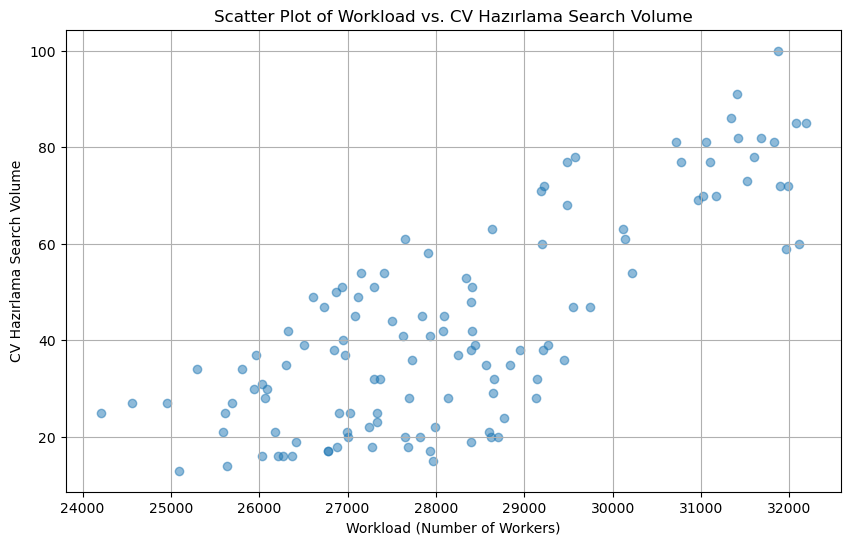

```python
import matplotlib.pyplot as plt

merged_data = pd.merge(workforce_data, search_volume_kw6, on='Tarih', how='inner')

plt.figure(figsize=(10, 6))
plt.scatter(merged_data['m_işgücü'], merged_data['cv hazırlama'], alpha=0.5)
plt.title('Scatter Plot of Workload vs. CV Hazırlama Search Volume')
plt.xlabel('Workload (Number of Workers)')
plt.ylabel('CV Hazırlama Search Volume')
plt.grid(True)
plt.show()
```

The scatter plot shows the relationship between workforce size and "CV Hazırlama" search volume. Observations include:

- A general positive correlation: higher workforce numbers often coincide with increased search volume.
- Variability in search volume appears to grow with the workforce size.
- The data points do not display any significant anomalies, suggesting a stable relationship across the range.

I will continue with building a linear model with 'cv hazırlama' search volume.

```python
import statsmodels.api as sm

dfs = [workforce_data, search_volume_kw6]
merged_data = reduce(lambda left, right: pd.merge(left, right, on='Tarih', how='inner'), dfs)

X = merged_data[['cv hazırlama']]
y = merged_data['m_işgücü']

# Add a constant to the model (the intercept)
X = sm.add_constant(X)

# Fit the model
model = sm.OLS(y, X).fit()

# Print out the statistics
model_summary = model.summary()
print(model_summary)
```

```
                            OLS Regression Results
==============================================================================
Dep. Variable:               m_işgücü   R-squared:                       0.600
Model:                            OLS   Adj. R-squared:                  0.597
Method:                 Least Squares   F-statistic:                     178.5
Date:                Fri, 05 Apr 2024   Prob (F-statistic):           1.97e-25
Time:                        20:41:39   Log-Likelihood:                -1031.6
No. Observations:                 121   AIC:                             2067.
Df Residuals:                     119   BIC:                             2073.
Df Model:                           1
Covariance Type:            nonrobust
================================================================================
                   coef    std err          t      P>|t|      [0.025      0.975]
--------------------------------------------------------------------------------
const         2.526e+04    249.406    101.268      0.000    2.48e+04    2.58e+04
cv hazırlama    69.1732      5.177     13.361      0.000      58.921      79.425
==============================================================================
Omnibus:                        7.479   Durbin-Watson:                   0.312
Prob(Omnibus):                  0.024   Jarque-Bera (JB):                3.388
Skew:                          -0.102   Prob(JB):                        0.184
Kurtosis:                       2.206   Cond. No.                         107.
==============================================================================

Notes:
[1] Standard Errors assume that the covariance matrix of the errors is correctly specified.
```

With an adjusted R-squared value of 0.6, the search volume for "CV Hazırlama" proves to be a significant predictor for the workforce time series. I will now incorporate additional variables with correlations of 0.28 and -0.31 to the model to test their significance and observe any changes in the adjusted R-squared value.

```python
dfs = [workforce_data, search_volume_kw6,search_volume_kw2, search_volume_kw3, search_volume_kw5]
merged_data = reduce(lambda left, right: pd.merge(left, right, on='Tarih', how='inner'), dfs)

X = merged_data[['cv hazırlama', 'uzaktan çalışma', 'işsizlik maaşı', 'iş görüşmesi']]
y = merged_data['m_işgücü']

# Add a constant to the model (the intercept)
X = sm.add_constant(X)

# Fit the model
model = sm.OLS(y, X).fit()

# Print out the statistics
model_summary = model.summary()
print(model_summary)
```

```
                            OLS Regression Results
==============================================================================
Dep. Variable:               m_işgücü   R-squared:                       0.624
Model:                            OLS   Adj. R-squared:                  0.611
Method:                 Least Squares   F-statistic:                     48.15
Date:                Fri, 05 Apr 2024   Prob (F-statistic):           8.42e-24
Time:                        20:50:15   Log-Likelihood:                -1027.8
No. Observations:                 121   AIC:                             2066.
Df Residuals:                     116   BIC:                             2080.
Df Model:                           4
Covariance Type:            nonrobust
===================================================================================
                      coef    std err          t      P>|t|      [0.025      0.975]
-----------------------------------------------------------------------------------
const            2.525e+04    983.259     25.678      0.000    2.33e+04    2.72e+04
cv hazırlama       72.5139      6.002     12.082      0.000      60.626      84.402
uzaktan çalışma   -16.6735      8.569     -1.946      0.054     -33.645       0.298
işsizlik maaşı     14.4120      8.373      1.721      0.088      -2.172      30.996
iş görüşmesi       -6.7639     12.499     -0.541      0.589     -31.519      17.991
==============================================================================
Omnibus:                        2.397   Durbin-Watson:                   0.410
Prob(Omnibus):                  0.302   Jarque-Bera (JB):                1.715
Skew:                          -0.076   Prob(JB):                        0.424
Kurtosis:                       2.437   Cond. No.                         781.
==============================================================================

Notes:
[1] Standard Errors assume that the covariance matrix of the errors is correctly specified.
```

The OLS regression results show that "cv hazırlama" is a significant predictor for the workforce time series with a coefficient of 72.5139 and a p-value of 0.000. Although "uzaktan çalışma" and "işsizlik maaşı" have been included in the model, their p-values suggest that they are marginally significant and may not be robust predictors. The adjusted R-squared value of 0.611 indicates that approximately 61.1% of the variability in the workforce data is explained by the model.

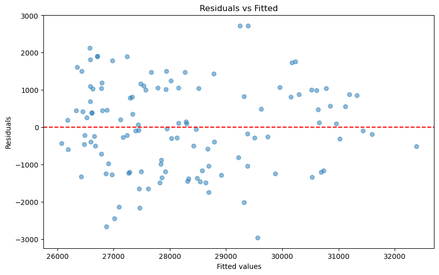

```python
residuals = model.resid
fitted = model.fittedvalues

plt.figure(figsize=(10, 6))
plt.scatter(fitted, residuals, alpha=0.5)
plt.axhline(0, color='red', linestyle='--')
plt.xlabel('Fitted values')
plt.ylabel('Residuals')
plt.title('Residuals vs Fitted')
plt.show()
```

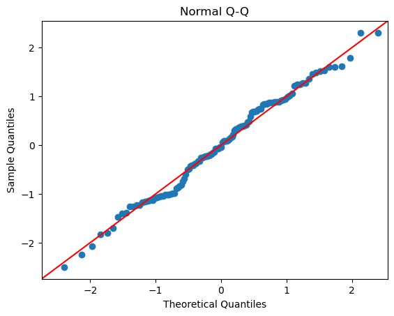

```python
#qq plot
fig = sm.qqplot(residuals, line='45', fit=True)
plt.title('Normal Q-Q')
plt.show()
```

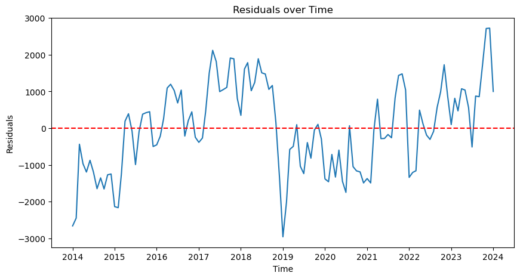

```python
plt.figure(figsize=(10, 5))
plt.plot(model.resid)
plt.title('Residuals over Time')
plt.xlabel('Time')
plt.ylabel('Residuals')
plt.axhline(0, linestyle='--', color='red')
plt.show()
```

## Regression Diagnostics

[Residuals vs Fitted Plot] In the Residuals vs Fitted plot, the residuals are reasonably scattered around the zero line without a discernible pattern, indicating no major issues with non-linearity.

[Normal Q-Q Plot] The Normal Q-Q plot reveals that the residuals closely follow the theoretical quantiles, except for slight deviations in the tails, suggesting that the residuals are approximately normally distributed with some potential outliers.

[Residuals over Time Plot] The Residuals over Time plot, however, hints at some patterns in residuals over time. This could be an indication of trends or autocorrelation not captured by the model. I will investigate these patterns further by examining the Autocorrelation Function (ACF) to identify the source of these trends.

This comprehensive diagnostic evaluation indicates that while the model accounts for a significant portion of variability, there are aspects, such as potential trends in residuals, that require further investigation to refine the model.

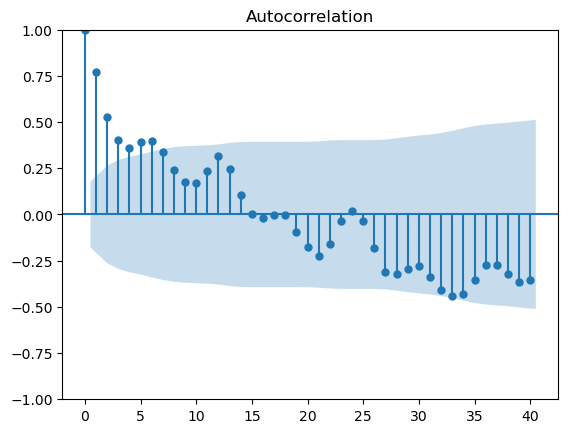

```python
from statsmodels.graphics.tsaplots import plot_acf

plot_acf(model.resid, lags=40)
plt.show()
```

## Further Model Refinement Based on ACF Analysis

Upon examining the Autocorrelation Function (ACF), the initial lag presents a significant autocorrelation that was not captured by the original model, hinting at a potential underlying trend. Moreover, an observed spike in the ACF at the 12th lag suggests a yearly seasonality effect. To address these insights, I am going to incorporate both a time trend and seasonal dummy variables into the regression model. This enhancement is expected to better accommodate the temporal structure and seasonal influences within the workforce data.

## Modeling Changing Trends and COVID-19 Impact

In the workforce time series, the trend appears to shift at two critical junctures. There is an increasing trend up until January 2019, followed by a distinct second increasing trend from March 2020 to the present. These phases likely reflect different economic conditions or policy environments. To accurately model these trends, I will introduce piecewise linear trends in the regression, allowing for slope changes at these points.

Additionally, given the global onset of the COVID-19 pandemic around March 2020, I will also include a dummy variable to capture any deviations during this period that are not explained by the usual trend. This will provide a clearer understanding of the pandemic's impact on the workforce data.

```python
import pandas as pd
import numpy as np
import statsmodels.api as sm
from functools import reduce

independent_vars_filenames = [
    'gt_cvhazırlama', 'gt_uzaktançalışma',
    'gt_işsizlikmaaşı', 'gt_işgörüşmesi'
]

dep_data = pd.read_excel('./ie360_hw1/m_işgücü.xlsx', usecols="A:B")
dep_data.columns = ['Tarih', 'm_işgücü']
dep_data['Tarih'] = pd.to_datetime(dep_data['Tarih'], format='%Y-%m')
dep_data.set_index('Tarih', inplace=True)

independent_vars_df = pd.DataFrame(index=dep_data.index)

# Process each independent variable
for filename in independent_vars_filenames:
    temp_df = pd.read_csv(f'./ie360_hw1/{filename}.csv', header=1)
    temp_df.columns = ['Ay', 'value']
    temp_df['Ay'] = pd.to_datetime(temp_df['Ay'], format='%Y-%m')
    temp_df.set_index('Ay', inplace=True)
    independent_vars_df = independent_vars_df.join(temp_df['value'].rename(filename), how='left')


independent_vars_df.dropna(inplace=True)

# Merge the independent and dependent variables
merged_data = pd.concat([dep_data, independent_vars_df], axis=1)

# The final merged DataFrame has no NaN values
merged_data.dropna(inplace=True)

merged_data['Trend1'] = np.where(merged_data.index < pd.Timestamp('2019-01'),
                                 (merged_data.index - pd.Timestamp('2014-01')).days, 0)
merged_data['Trend2'] = np.where(merged_data.index > pd.Timestamp('2020-03'),
                                 (merged_data.index - pd.Timestamp('2020-03')).days, 0)

# Create a COVID-19 dummy variable for the period from March 2020 to April 2021
merged_data['COVID_dummy'] = np.where((merged_data.index >= pd.Timestamp('2020-03')) &
                                      (merged_data.index <= pd.Timestamp('2021-04')), 1, 0)

# Prepare the X and y for the model, including the new variables
X = sm.add_constant(pd.concat([
    merged_data[independent_vars_filenames],
    merged_data[['Trend1', 'Trend2', 'COVID_dummy']]
], axis=1))

y = merged_data['m_işgücü']

# Fit the OLS regression model
model = sm.OLS(y, X.astype(float)).fit()  # Convert X to float to avoid errors

# Output the summary of the regression model
print(model.summary())
```

```
                            OLS Regression Results
==============================================================================
Dep. Variable:               m_işgücü   R-squared:                       0.862
Model:                            OLS   Adj. R-squared:                  0.853
Method:                 Least Squares   F-statistic:                     100.6
Date:                Fri, 05 Apr 2024   Prob (F-statistic):           1.54e-45
Time:                        21:26:29   Log-Likelihood:                -967.33
No. Observations:                 121   AIC:                             1951.
Df Residuals:                     113   BIC:                             1973.
Df Model:                           7
Covariance Type:            nonrobust
=====================================================================================
                        coef    std err          t      P>|t|      [0.025      0.975]
-------------------------------------------------------------------------------------
const              2.448e+04    671.456     36.459      0.000    2.32e+04    2.58e+04
gt_cvhazırlama       41.8591      7.030      5.954      0.000      27.931      55.787
gt_uzaktançalışma     1.4973      7.670      0.195      0.846     -13.699      16.694
gt_işsizlikmaaşı      6.8941      5.425      1.271      0.206      -3.854      17.642
gt_işgörüşmesi        6.2399     10.184      0.613      0.541     -13.937      26.417
Trend1                1.2843      0.164      7.825      0.000       0.959       1.609
Trend2                2.8369      0.440      6.444      0.000       1.965       3.709
COVID_dummy        -614.4495    433.707     -1.417      0.159   -1473.701     244.802
==============================================================================
Omnibus:                        2.003   Durbin-Watson:                   0.614
Prob(Omnibus):                  0.367   Jarque-Bera (JB):                1.877
Skew:                          -0.303   Prob(JB):                        0.391
Kurtosis:                       2.932   Cond. No.                     7.62e+03
==============================================================================

Notes:
[1] Standard Errors assume that the covariance matrix of the errors is correctly specified.
[2] The condition number is large, 7.62e+03. This might indicate that there are
strong multicollinearity or other numerical problems.
```

```python
# Create monthly dummies
merged_data['month'] = merged_data.index.month
month_dummies = pd.get_dummies(merged_data['month'], prefix='month', drop_first=True)

X = sm.add_constant(pd.concat([
    month_dummies,
    merged_data[independent_vars_filenames],
    merged_data[['Trend1', 'Trend2', 'COVID_dummy']]
], axis=1))

y = merged_data['m_işgücü']

# Fit the OLS regression model
model = sm.OLS(y, X.astype(float)).fit()  # Convert X to float to avoid errors

# Output the summary of the regression model
print(model.summary())
```

```
                            OLS Regression Results
==============================================================================
Dep. Variable:               m_işgücü   R-squared:                       0.907
Model:                            OLS   Adj. R-squared:                  0.891
Method:                 Least Squares   F-statistic:                     55.43
Date:                Fri, 05 Apr 2024   Prob (F-statistic):           2.22e-44
Time:                        21:30:30   Log-Likelihood:                -943.16
No. Observations:                 121   AIC:                             1924.
Df Residuals:                     102   BIC:                             1977.
Df Model:                          18
Covariance Type:            nonrobust
=====================================================================================
                        coef    std err          t      P>|t|      [0.025      0.975]
-------------------------------------------------------------------------------------
const              2.375e+04    620.619     38.263      0.000    2.25e+04     2.5e+04
month_2             297.0515    282.758      1.051      0.296    -263.798     857.901
month_3             901.1289    293.469      3.071      0.003     319.035    1483.222
month_4            1173.7996    290.150      4.045      0.000     598.289    1749.311
month_5            1383.3264    287.860      4.806      0.000     812.358    1954.295
month_6            1329.1689    294.544      4.513      0.000     744.943    1913.395
month_7             965.9611    293.268      3.294      0.001     384.264    1547.658
month_8            1312.9646    295.524      4.443      0.000     726.795    1899.135
month_9            1204.2408    292.318      4.120      0.000     624.429    1784.053
month_10           1301.5698    286.925      4.536      0.000     732.456    1870.684
month_11           1279.7473    288.655      4.433      0.000     707.201    1852.293
month_12            637.6456    282.918      2.254      0.026      76.479    1198.813
gt_cvhazırlama       37.1942      6.871      5.413      0.000      23.565      50.823
gt_uzaktançalışma    -5.0769      6.944     -0.731      0.466     -18.851       8.697
gt_işsizlikmaaşı     16.5370      4.964      3.331      0.001       6.691      26.383
gt_işgörüşmesi        1.3524      9.162      0.148      0.883     -16.820      19.525
Trend1                1.1474      0.147      7.783      0.000       0.855       1.440
Trend2                2.9596      0.409      7.234      0.000       2.148       3.771
COVID_dummy        -509.9661    386.478     -1.320      0.190   -1276.543     256.611
==============================================================================
Omnibus:                        2.204   Durbin-Watson:                   0.605
Prob(Omnibus):                  0.332   Jarque-Bera (JB):                2.212
Skew:                          -0.280   Prob(JB):                        0.331
Kurtosis:                       2.645   Cond. No.                     9.63e+03
==============================================================================

Notes:
[1] Standard Errors assume that the covariance matrix of the errors is correctly specified.
[2] The condition number is large, 9.63e+03. This might indicate that there are
strong multicollinearity or other numerical problems.
```

## Regression Analysis Summaries

### Model Without Monthly Dummies

The initial OLS regression model (without monthly dummies) reports an R-squared value of 0.862, indicating that a significant portion of the variance in the workforce data is explained by the model. Key predictors such as 'cv_hazırlama' show a positive significant relationship with the workforce, whereas 'COVID_dummy' does not appear to be significant with a p-value of 0.159.

The model includes trend variables 'Trend1' and 'Trend2', both of which are significant, demonstrating distinct time-based changes in the workforce data. However, the high condition number suggests potential multicollinearity issues that may need to be addressed.

### Model With Monthly Dummies

Introducing monthly dummies significantly increases the adjusted R-squared value to 0.891, which indicates that the model with seasonality accounted for explains the variability in the workforce data even better. Each month has a unique coefficient, showing a clear seasonal pattern within the data.

### Conclusion

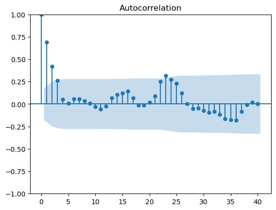

```python
from statsmodels.graphics.tsaplots import plot_acf

plot_acf(model.resid, lags=40)
plt.show()
```

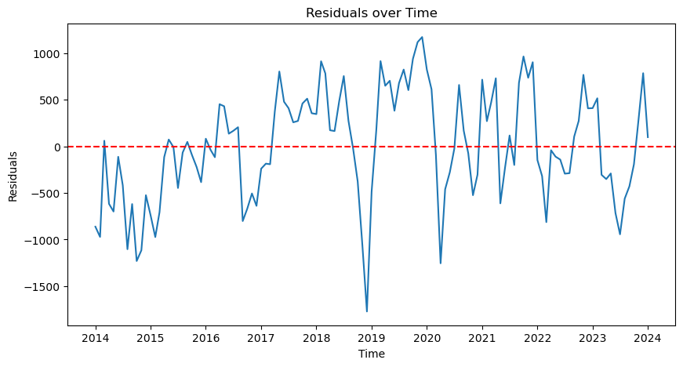

```python
plt.figure(figsize=(10, 5))
plt.plot(model.resid)
plt.title('Residuals over Time')
plt.xlabel('Time')
plt.ylabel('Residuals')
plt.axhline(0, linestyle='--', color='red')
plt.show()
```

## Summary of Regression Analysis and Path Forward

The regression analysis conducted has led to a model that effectively utilizes explanatory variables and dummy variables to capture the observable trends within the workforce time series data.

### Diagnostic Plots Analysis

- **ACF Plot Analysis**: The Autocorrelation Function plot indicates significant autocorrelation at the initial lags, hinting at the presence of momentum or inertia in the workforce data that the current model does not yet account for.
- **Residuals Over Time Analysis**: The plot of the residuals over time does not display a clear pattern, suggesting the main trends have been captured. However, the spread of residuals might be inconsistent across the time series, pointing towards potential heteroskedasticity.

### Accomplishments

- Successfully merged various time series datasets for analysis.
- Incorporated significant search trend data and COVID-related impact into the model.
- Adjusted for trends and seasonality by including relevant dummy variables.

### Considerations for Further Improvement

- **Addressing Heteroskedasticity**: Considering variance-stabilizing transformations like logarithms or Box-Cox on the dependent variable might be beneficial. For robust regression, the use of heteroskedasticity-consistent standard errors can provide more reliable inference.
- **Autocorrelation Mitigation**: Introducing lagged variables as predictors could account for the inertia indicated by the ACF plot, potentially through a simple autoregressive structure. This could further refine the model's accuracy.

## Analysis of Housing Market Trends in Turkey

The housing market is a significant component of the national economy, offering insights into consumer confidence and broader economic conditions. This analysis aims to explore the number of houses sold in Turkey from January 2014 through January 2024.

### Identifying Related Variables

In an effort to understand the factors influencing housing market activity, I will be considering both economic indicators and housing market-specific drivers. The variables selected for this study include:

- **Google Trends data**: Searches for terms such as "satılık ev" (houses for sale) and "sahibinden" (popular website), which may reflect the public's interest in purchasing houses.
- **Financial factors**: Monthly interest rates of house credits and the monthly average price per square meter for houses, as these could impact buyer affordability and market demand.

These variables were chosen for their potential to directly or indirectly influence the housing market. The subsequent steps in this analysis will involve investigating the relationship between these variables and the number of houses sold, providing valuable insights into the dynamics of Turkey's real estate sector.

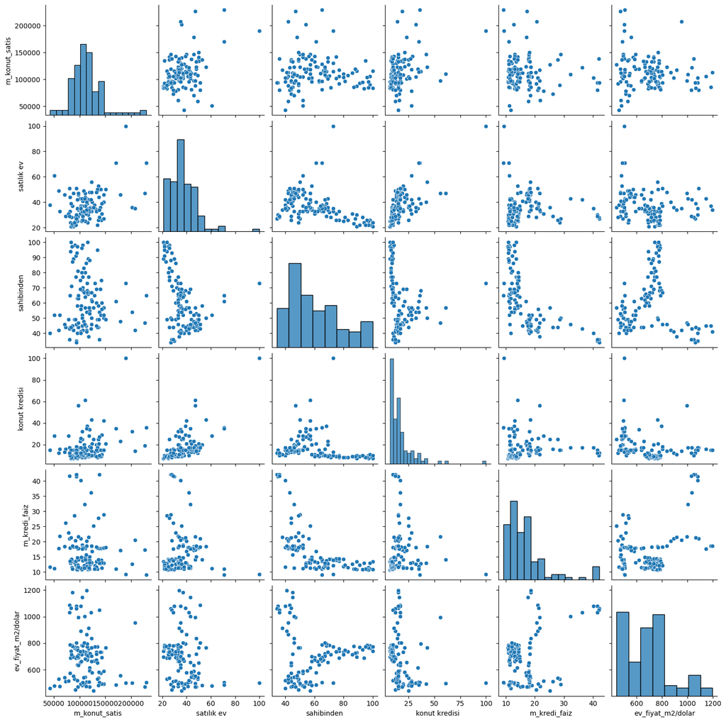

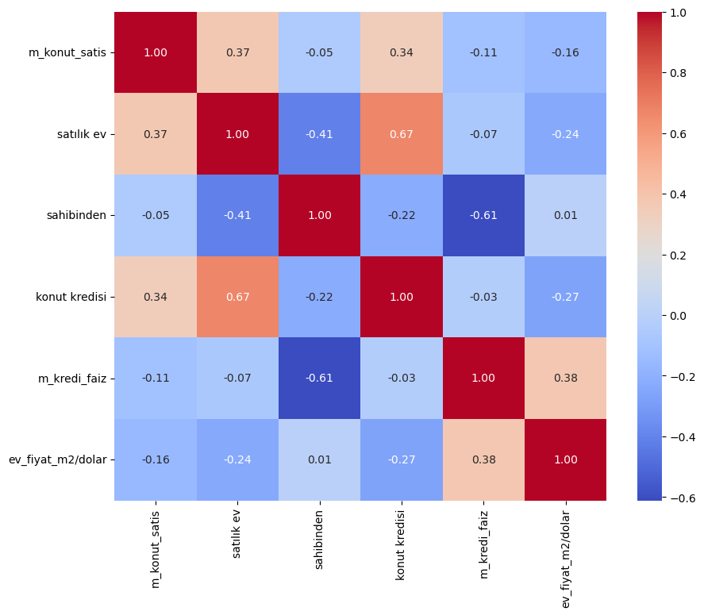

```python
file_path = './ie360_hw1/m_konut_satis.xlsx'
numberofhousesold = pd.read_excel(file_path, index_col='Tarih', parse_dates=True)

search_volume1 = pd.read_csv('./ie360_hw1/gt_satılıkev.csv', header=1)
search_volume1.columns = ['Tarih', 'satılık ev']
search_volume1['Tarih'] = pd.to_datetime(search_volume1['Tarih'])
search_volume1.set_index('Tarih', inplace=True)

search_volume2 = pd.read_csv('./ie360_hw1/gt_sahibinden.csv', header=1)
search_volume2.columns = ['Tarih', 'sahibinden']
search_volume2['Tarih'] = pd.to_datetime(search_volume2['Tarih'])
search_volume2.set_index('Tarih', inplace=True)

search_volume3 = pd.read_csv('./ie360_hw1/gt_konutkredisi.csv', header=1)
search_volume3.columns = ['Tarih', 'konut kredisi']
search_volume3['Tarih'] = pd.to_datetime(search_volume3['Tarih'])
search_volume3.set_index('Tarih', inplace=True)

search_volume4 = pd.read_excel('./ie360_hw1/m_kredi_faiz.xlsx', header=1)
search_volume4.columns = ['Tarih', 'm_kredi_faiz']
search_volume4['Tarih'] = pd.to_datetime(search_volume4['Tarih'])
search_volume4.set_index('Tarih', inplace=True)

search_volume5 = pd.read_excel('./ie360_hw1/m_ev_fiyat_m2dolar.xlsx', header=1)
search_volume5.columns = ['Tarih', 'ev_fiyat_m2/dolar']
search_volume5['Tarih'] = pd.to_datetime(search_volume5['Tarih'])
search_volume5.set_index('Tarih', inplace=True)


from functools import reduce

dfs = [numberofhousesold, search_volume1, search_volume2,search_volume3, search_volume4 , search_volume5]  # Add all your dataframes to this list
merged_data2 = reduce(lambda left, right: pd.merge(left, right, on='Tarih', how='inner'), dfs)

correlation_matrix = merged_data2.corr()

import seaborn as sns
import matplotlib.pyplot as plt

sns.pairplot(merged_data2)
plt.show()


plt.figure(figsize=(10, 8))
sns.heatmap(correlation_matrix, annot=True, cmap='coolwarm', fmt='.2f')
plt.show()
```

After an initial exploration of various factors that could influence the housing market in Turkey, I have identified two primary variables that show promising correlations with the number of houses sold: "satılık ev" (houses for sale) and "konut kredisi" (housing loans). These variables represent critical aspects of the housing market—buyer interest and financing conditions, respectively.

```python
import statsmodels.api as sm

dfs = [numberofhousesold, search_volume1, search_volume3]  # Add all your dataframes to this list
merged_data2 = reduce(lambda left, right: pd.merge(left, right, on='Tarih', how='inner'), dfs)

X = merged_data2[['satılık ev',  'konut kredisi']]
y = merged_data2['m_konut_satis']

# Add a constant to the model (the intercept)
X = sm.add_constant(X)

# Fit the model
model2 = sm.OLS(y, X).fit()

# Print out the statistics
model2_summary = model2.summary()
print(model2_summary)
```

```
                            OLS Regression Results
==============================================================================
Dep. Variable:          m_konut_satis   R-squared:                       0.156
Model:                            OLS   Adj. R-squared:                  0.141
Method:                 Least Squares   F-statistic:                     10.87
Date:                Fri, 05 Apr 2024   Prob (F-statistic):           4.65e-05
Time:                        22:12:03   Log-Likelihood:                -1410.5
No. Observations:                 121   AIC:                             2827.
Df Residuals:                     118   BIC:                             2835.
Df Model:                           2
Covariance Type:            nonrobust
=================================================================================
                    coef    std err          t      P>|t|      [0.025      0.975]
---------------------------------------------------------------------------------
const          7.968e+04   9216.031      8.645      0.000    6.14e+04    9.79e+04
satılık ev      731.6726    306.973      2.384      0.019     123.783    1339.563
konut kredisi   390.5806    283.944      1.376      0.172    -171.707     952.868
==============================================================================
Omnibus:                       24.683   Durbin-Watson:                   1.599
Prob(Omnibus):                  0.000   Jarque-Bera (JB):               60.444
Skew:                           0.758   Prob(JB):                     7.50e-14
Kurtosis:                       6.113   Cond. No.                         154.
==============================================================================

Notes:
[1] Standard Errors assume that the covariance matrix of the errors is correctly specified.
```

The OLS regression results indicate that the selected variables, "satılık ev" and "konut kredisi," have not yielded as promising results as anticipated. The variable "satılık ev" shows some significance, but "konut kredisi" does not. To enhance the model, it's appropriate to consider incorporating trend and seasonality components.

The next steps will involve incorporating a time trend to account for non-seasonal growth or decline in house sales over the years, as well as seasonal dummies that can capture specific monthly fluctuations. This approach aims to improve the model's explanatory power by accounting for more nuanced patterns in the data.

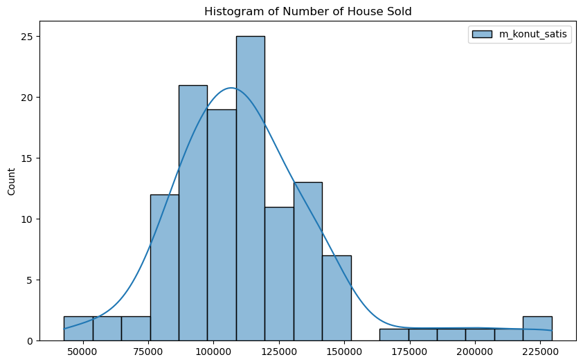

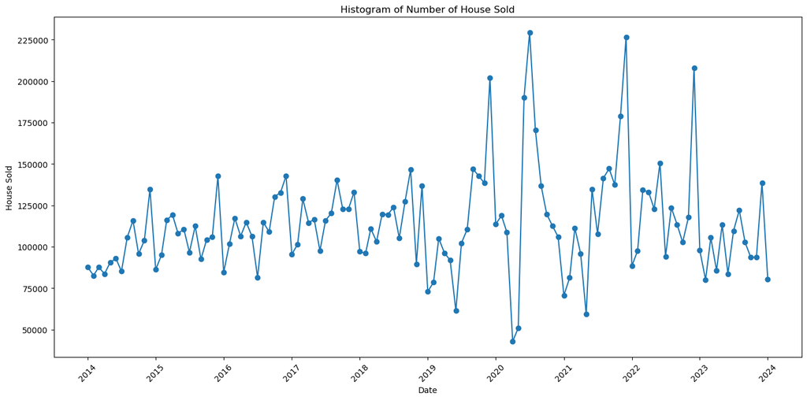

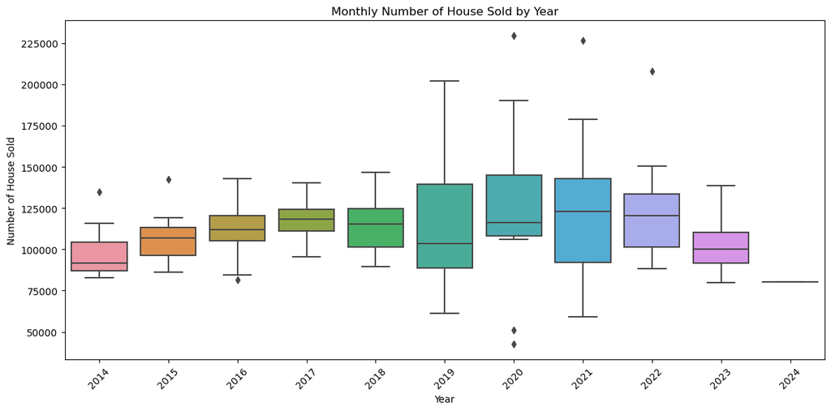

```python
plt.figure(figsize=(10, 6))
sns.histplot(data=numberofhousesold, kde=True)
plt.title('Histogram of Number of House Sold')
plt.show()
plt.figure(figsize=(14, 7))
plt.plot(numberofhousesold.index, numberofhousesold['m_konut_satis'], marker='o', linestyle='-')
plt.title('Histogram of Number of House Sold')
plt.xlabel('Date')
plt.ylabel('House Sold')
plt.xticks(rotation=45)
plt.tight_layout()
plt.show()

df1 = pd.read_excel('./ie360_hw1/m_konut_satis.xlsx', parse_dates=['Tarih'])

df1['Year'] = df1['Tarih'].dt.year

fig, ax = plt.subplots(figsize=(12, 6))

sns.boxplot(ax=ax, x='Year', y='m_konut_satis', data=df1)
ax.set_title('Monthly Number of House Sold by Year')
ax.set_ylabel('Number of House Sold')
ax.set_xlabel('Year')

ax.set_xticklabels(ax.get_xticklabels(), rotation=45)

plt.tight_layout()
plt.show()
```

## Preliminary Analysis of Housing Market Data

The exploration of the housing market in Turkey begins with visualizing the distribution and time-series patterns of house sales.

- The **Histogram of Number of Houses Sold** shows a distribution that suggests a concentration of monthly sales around a central value with some months showing higher and lower sales, hinting at potential outliers or periods of unusual activity.
- The **Time Series Plot of House Sales** reveals clear fluctuations over time, which may be indicative of underlying seasonal trends or cyclical economic factors affecting the housing market.
- The **Box Plot Grouped by Year** offers a view of the central tendency and dispersion of house sales by year, which could inform the presence of a trend over the years examined.

### Incorporating a Trend Variable

As a first step in refining the model, a trend variable will be introduced to capture any long-term increase or decrease in house sales over the time period. This trend variable will account for the potential non-stationarity in the series, providing a foundation for further analysis of other factors influencing the housing market.

```python
import pandas as pd
import numpy as np
import statsmodels.api as sm
from functools import reduce


merged_data2['Trend_Increase'] = np.where(merged_data2.index < '2019-01-01', np.arange(len(merged_data2)), 0)
merged_data2['Trend_Stationary'] = np.where((merged_data2.index >= '2019-01-01') & (merged_data2.index < '2022-01-01'), 1, 0)
max_trend_value = merged_data2['Trend_Increase'].max()
merged_data2['Trend_Decrease'] = np.where(merged_data2.index >= '2022-01-01', np.arange(len(merged_data2)), 0)
merged_data2['Trend_Decrease'] = merged_data2['Trend_Decrease'].apply(lambda x: max_trend_value - x if x > 0 else 0)

# Adding the trend variables to the independent variables
independent_vars = [ 'satılık ev', 'konut kredisi', 'Trend_Increase', 'Trend_Stationary', 'Trend_Decrease']
X = sm.add_constant(pd.concat([ merged_data2[independent_vars]], axis=1))
y= merged_data2['m_konut_satis']
# Fit the OLS regression model
model2 = sm.OLS(y, X.astype(float)).fit()

# Output the summary of the regression model
model2_summary = model2.summary()
print(model2_summary)
```

```
                            OLS Regression Results
==============================================================================
Dep. Variable:          m_konut_satis   R-squared:                       0.176
Model:                            OLS   Adj. R-squared:                  0.140
Method:                 Least Squares   F-statistic:                     4.917
Date:                Fri, 05 Apr 2024   Prob (F-statistic):           0.000409
Time:                        22:19:13   Log-Likelihood:                -1409.0
No. Observations:                 121   AIC:                             2830.
Df Residuals:                     115   BIC:                             2847.
Df Model:                           5
Covariance Type:            nonrobust
====================================================================================
                       coef    std err          t      P>|t|      [0.025      0.975]
------------------------------------------------------------------------------------
const             7.302e+04   1.05e+04      6.966      0.000    5.23e+04    9.38e+04
satılık ev         857.2445    340.327      2.519      0.013     183.122    1531.367
konut kredisi      375.2227    287.971      1.303      0.195    -195.193     945.639
Trend_Increase     202.7308    214.984      0.943      0.348    -223.110     628.572
Trend_Stationary  -112.2376   1.02e+04     -0.011      0.991   -2.03e+04       2e+04
Trend_Decrease      63.9993    199.649      0.321      0.749    -331.468     459.466
==============================================================================
Omnibus:                       31.237   Durbin-Watson:                   1.626
Prob(Omnibus):                  0.000   Jarque-Bera (JB):               87.513
Skew:                           0.924   Prob(JB):                     9.93e-20
Kurtosis:                       6.734   Cond. No.                         199.
==============================================================================

Notes:
[1] Standard Errors assume that the covariance matrix of the errors is correctly specified.
```

```python
merged_data2['covid_dummy'] = ((merged_data2.index >= '2020-03') & (merged_data2.index <= '2021-04')).astype(int)

independent_vars = [ 'satılık ev',  'konut kredisi', 'covid_dummy', 'Trend_Increase',  'Trend_Decrease']
X = sm.add_constant(pd.concat([ merged_data2[independent_vars]], axis=1))
y= merged_data2['m_konut_satis']
# Fit the OLS regression model
model2 = sm.OLS(y, X.astype(float)).fit()

# Output the summary of the regression model
model2_summary = model2.summary()
print(model2_summary)
```

```
                            OLS Regression Results
==============================================================================
Dep. Variable:          m_konut_satis   R-squared:                       0.205
Model:                            OLS   Adj. R-squared:                  0.171
Method:                 Least Squares   F-statistic:                     5.936
Date:                Fri, 05 Apr 2024   Prob (F-statistic):           6.42e-05
Time:                        22:17:02   Log-Likelihood:                -1406.8
No. Observations:                 121   AIC:                             2826.
Df Residuals:                     115   BIC:                             2842.
Df Model:                           5
Covariance Type:            nonrobust
==================================================================================
                     coef    std err          t      P>|t|      [0.025      0.975]
----------------------------------------------------------------------------------
const           6.678e+04   1.06e+04      6.276      0.000    4.57e+04    8.79e+04
satılık ev      1220.1152    357.771      3.410      0.001     511.440    1928.790
konut kredisi    254.8136    286.757      0.889      0.376    -313.197     822.824
covid_dummy    -2.091e+04   1.02e+04     -2.048      0.043   -4.11e+04    -687.150
Trend_Increase   102.9076    155.799      0.661      0.510    -205.700     411.515
Trend_Decrease   188.0638    150.217      1.252      0.213    -109.488     485.616
==============================================================================
Omnibus:                       31.078   Durbin-Watson:                   1.732
Prob(Omnibus):                  0.000   Jarque-Bera (JB):               80.263
Skew:                           0.953   Prob(JB):                     3.72e-18
Kurtosis:                       6.505   Cond. No.                         217.
==============================================================================

Notes:
[1] Standard Errors assume that the covariance matrix of the errors is correctly specified.
```

## Analysis of Regression Results for House Sales in Turkey

The OLS regression models aim to capture the trends and impacts on the number of houses sold in Turkey, with the inclusion of Google Trends data for "satılık ev" and interest rates for "konut kredisi."

### Model with Trend Variables

The first model, which incorporates trend variables for increase, stationary, and decrease periods, suggests that "satılık ev" is a statistically significant predictor, whereas "konut kredisi" and the trend variables do not show statistical significance at conventional levels.

### Model with COVID-19 Period Dummy

Adjusting the model to replace the stationary trend variable with a COVID-19 period dummy leads to a slight improvement in the adjusted R-squared value. "Satılık ev" remains a significant predictor. The COVID-19 dummy variable is significant, indicating a notable impact on the number of houses sold during the pandemic.

### Conclusions

These analyses reveal the fluctuating nature of the housing market and the importance of external events such as the COVID-19 pandemic. The significant coefficient for "satılık ev" aligns with expectations that online search interest can reflect real-world buying behavior.

### Next Steps

With the current regression analysis indicating the relevance of specific predictors, my immediate next step will be to examine the Autocorrelation Function (ACF) plot. This will help to determine the presence and nature of seasonality in the number of houses sold. A discernible pattern in the ACF plot may suggest that incorporating seasonal lags into the model could capture periodic fluctuations and enhance the model's explanatory power.

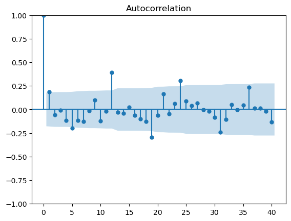

```python
from statsmodels.graphics.tsaplots import plot_acf

plot_acf(model2.resid, lags=40)
plt.show()
```

## Incorporating Seasonality with Monthly Dummy Variable

To address this seasonality and improve the model's accuracy, a monthly dummy variable will be added. This variable will encode the month of the year as categorical indicators, allowing the regression model to capture the systematic variations in house sales across different months.

```python
merged_data2['month'] = merged_data2.index.month
month_dummies = pd.get_dummies(merged_data2['month'], prefix='month', drop_first=True)
independent_vars = ['satılık ev',  'konut kredisi', 'covid_dummy', 'Trend_Increase', 'Trend_Stationary', 'Trend_Decrease']
X = sm.add_constant(pd.concat([month_dummies, merged_data2[independent_vars]], axis=1))
y= merged_data2['m_konut_satis']
# Fit the OLS regression model
model2 = sm.OLS(y, X.astype(float)).fit()

# Output the summary of the regression model
model2_summary = model2.summary()
print(model2_summary)
```

```
                            OLS Regression Results
==============================================================================
Dep. Variable:          m_konut_satis   R-squared:                       0.590
Model:                            OLS   Adj. R-squared:                  0.522
Method:                 Least Squares   F-statistic:                     8.705
Date:                Fri, 05 Apr 2024   Prob (F-statistic):           2.24e-13
Time:                        22:49:34   Log-Likelihood:                -1366.8
No. Observations:                 121   AIC:                             2770.
Df Residuals:                     103   BIC:                             2820.
Df Model:                          17
Covariance Type:            nonrobust
====================================================================================
                       coef    std err          t      P>|t|      [0.025      0.975]
------------------------------------------------------------------------------------
const             3.709e+04   1.01e+04      3.683      0.000    1.71e+04    5.71e+04
month_2           -460.8496   9303.380     -0.050      0.961   -1.89e+04     1.8e+04
month_3           2.425e+04   9297.959      2.609      0.010    5814.389    4.27e+04
month_4           1.367e+04   9342.556      1.463      0.147   -4862.770    3.22e+04
month_5           4840.4655   9276.515      0.522      0.603   -1.36e+04    2.32e+04
month_6           1.393e+04   9374.657      1.486      0.140   -4659.648    3.25e+04
month_7           1.442e+04   9484.382      1.520      0.132   -4392.917    3.32e+04
month_8           1.963e+04   9422.553      2.083      0.040     939.878    3.83e+04
month_9            3.06e+04   9277.155      3.299      0.001    1.22e+04     4.9e+04
month_10          3.264e+04   9289.944      3.513      0.001    1.42e+04    5.11e+04
month_11          3.602e+04   9307.873      3.870      0.000    1.76e+04    5.45e+04
month_12           7.37e+04   9320.976      7.907      0.000    5.52e+04    9.22e+04
satılık ev        1721.9526    301.496      5.711      0.000    1124.006    2319.899
konut kredisi      171.0815    225.555      0.758      0.450    -276.254     618.417
covid_dummy      -2.788e+04   8160.832     -3.416      0.001   -4.41e+04   -1.17e+04
Trend_Increase    -134.0452    164.864     -0.813      0.418    -461.014     192.924
Trend_Stationary -9034.1445   8005.828     -1.128      0.262   -2.49e+04    6843.528
Trend_Decrease     406.1004    156.062      2.602      0.011      96.587     715.613
==============================================================================
Omnibus:                       18.339   Durbin-Watson:                   1.771
Prob(Omnibus):                  0.000   Jarque-Bera (JB):               69.990
Skew:                           0.302   Prob(JB):                     6.34e-16
Kurtosis:                       6.677   Cond. No.                         557.
==============================================================================

Notes:
[1] Standard Errors assume that the covariance matrix of the errors is correctly specified.
```

## OLS Regression Results for House Sales in Turkey

### Key Findings:

- **Monthly Dummies**: The coefficients for the monthly dummy variables collectively contribute significantly to explaining seasonality in house sales.
- **Predictors**: The variables "satılık ev" (houses for sale) and "covid_dummy" (COVID-19 period) remain significant predictors of house sales.
- **Trend Variables**: The trend variables ("Trend_Increase", "Trend_Stationary", "Trend_Decrease") show mixed results, with only the "Trend_Decrease" variable being statistically significant.

### Conclusion:

Incorporating monthly dummy variables has notably improved the model's explanatory power, suggesting a better capture of seasonality in house sales. The coefficients for December indicate a significant spike in sales, possibly due to year-end factors. Other predictors also contribute to the model's effectiveness in explaining variations in house sales over time.

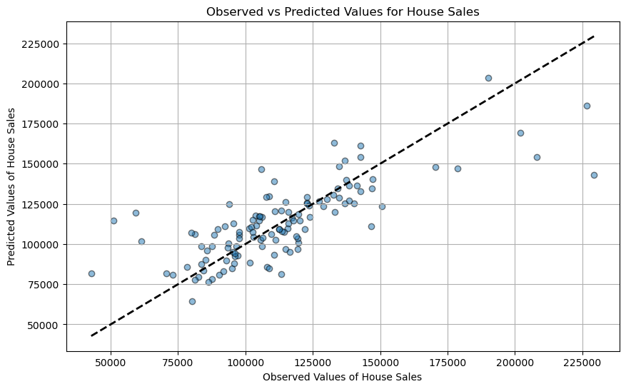

```python
predicted_values = model2.fittedvalues  # Get the predicted values from the model
observed_values = merged_data2['m_konut_satis']  # These are the actual observed values from your data

# Scatter plot of observed vs predicted values
plt.figure(figsize=(10, 6))  # You can adjust the figure size as needed
plt.scatter(observed_values, predicted_values, edgecolors='k', alpha=0.5)
plt.plot([observed_values.min(), observed_values.max()],
         [observed_values.min(), observed_values.max()], 'k--', lw=2)

plt.xlabel('Observed Values of House Sales')
plt.ylabel('Predicted Values of House Sales')
plt.title('Observed vs Predicted Values for House Sales')
plt.grid(True)
plt.show()
```

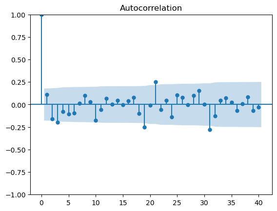

```python
from statsmodels.graphics.tsaplots import plot_acf

plot_acf(model2.resid, lags=40)
plt.show()
```

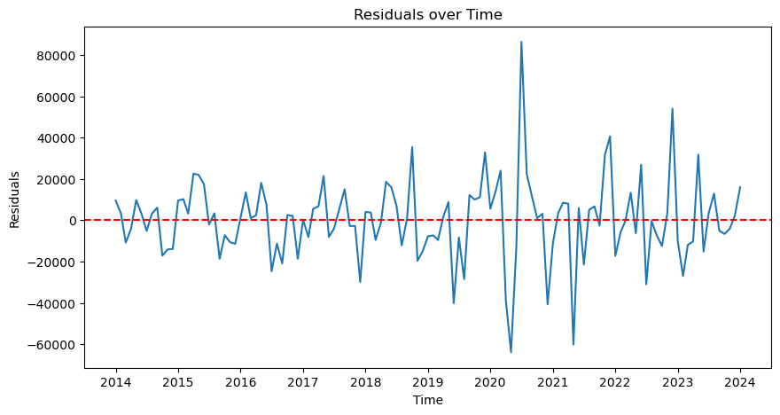

```python
plt.figure(figsize=(10, 5))
plt.plot(model2.resid)
plt.title('Residuals over Time')
plt.xlabel('Time')
plt.ylabel('Residuals')
plt.axhline(0, linestyle='--', color='red')
plt.show()
```

## Analysis of Autocorrelation and Residual Variance

### Suggestions for Improvement:

1. **Autocorrelation Correction**: Incorporating autoregressive elements into the model to account for the serial correlation in the residuals. Including lagged values of the dependent variable or additional lagged predictors may help address this issue.
2. **Heteroskedasticity Adjustment**: Applying transformation techniques such as logarithmic or square root transformations to stabilize the variance of the residuals. Alternatively, robust standard errors or weighted least squares regression can be used to mitigate the impact of heteroskedasticity on the model's estimates.

## Preliminary Analysis of Number of Tractor Produced Data

In this analysis, I delve into the time series of tractor production in Turkey spanning from January 2014 to January 2024. Tractors play a pivotal role in agricultural productivity, making their production an essential indicator of agricultural sector dynamics and broader economic trends.

## Factors Influencing Tractor Production

To understand the variables that may influence tractor production levels, we will explore a variety of potential correlates and impacts. Below are the variables under consideration:

### Google Trends Search Keywords:

- `tarım fuarı` (Agricultural Fair)
- `çiftçi kredisi` (Farmer Credit)

### BIST Food Sector Values:

- Stock market values for the food sector on the Borsa Istanbul (BIST) over the corresponding timespan.

### Monthly Oil Expense for Credit Cards:

- An estimate of monthly petrol prices, informed by credit card expenses on oil-related purchases.

### Monthly Production Involvement Rate for Turkey:

- The rate of involvement in production activities, including metal production, measured monthly.

### Agricultural Credit Amount:

- The cumulative credit provided to the agricultural sector by banks annually.

### Vehicle Production Numbers:

- **Cars**: The total number of cars produced in Turkey annually.
- **Trucks**: The total number of trucks produced in Turkey annually.
- **Small Trucks**: The total number of small trucks produced in Turkey annually.

[figure not shown]

[figure not shown]

```python
import pandas as pd
import numpy as np
import statsmodels.api as sm

file_path = './ie360_hw1/m_traktör_üretim.xlsx'
numberoftractorproduced = pd.read_excel(file_path, index_col='Tarih', parse_dates=True)

search_volume1 = pd.read_csv('./ie360_hw1/gt_tarımfuarı.csv', header=1)
search_volume1.columns = ['Tarih', 'tarım fuarı']
search_volume1['Tarih'] = pd.to_datetime(search_volume1['Tarih'])
search_volume1.set_index('Tarih', inplace=True)

search_volume3 = pd.read_csv('./ie360_hw1/gt_çiftçikredisi.csv', header=1)
search_volume3.columns = ['Tarih', 'çiftçi kredisi']
search_volume3['Tarih'] = pd.to_datetime(search_volume3['Tarih'])
search_volume3.set_index('Tarih', inplace=True)

search_volume4 = pd.read_excel('./ie360_hw1/BISTGıda.xlsx', header=1)
search_volume4.columns = ['Tarih', 'BISTGıda']
search_volume4['Tarih'] = pd.to_datetime(search_volume4['Tarih'])
search_volume4.set_index('Tarih', inplace=True)

search_volume2 = pd.read_excel('./ie360_hw1/m_kredikartı_benzin.xlsx', header=1)
search_volume2.columns = ['Tarih', 'm_kredikartı_benzin']
search_volume2['Tarih'] = pd.to_datetime(search_volume2['Tarih'])
search_volume2.set_index('Tarih', inplace=True)

search_volume6 = pd.read_excel('./ie360_hw1/m_imalatkatılımoranı.xlsx', header=1)
search_volume6.columns = ['Tarih', 'm_imalatkatılımoranı']
search_volume6['Tarih'] = pd.to_datetime(search_volume6['Tarih'])
search_volume6.set_index('Tarih', inplace=True)

search_volume5 = pd.read_excel('./ie360_hw1/m_geçinmeindex.xlsx', header=1)
search_volume5.columns = ['Tarih', 'm_geçinmeindex']
search_volume5['Tarih'] = pd.to_datetime(search_volume5['Tarih'])
search_volume5.set_index('Tarih', inplace=True)

search_volume7 = pd.read_excel('./ie360_hw1/m_tarım_kredi.xlsx', header=1)
search_volume7.columns = ['Tarih', 'm_tarım_kredi']
search_volume7['Tarih'] = pd.to_datetime(search_volume7['Tarih'])
search_volume7.set_index('Tarih', inplace=True)

search_volume8 = pd.read_excel('./ie360_hw1/m_binekaraçüretim.xlsx', header=1)
search_volume8.columns = ['Tarih', 'm_binekaraçüretim']
search_volume8['Tarih'] = pd.to_datetime(search_volume8['Tarih'])
search_volume8.set_index('Tarih', inplace=True)

search_volume9 = pd.read_excel('./ie360_hw1/m_kamyonüretim.xlsx', header=1)
search_volume9.columns = ['Tarih', 'm_kamyonüretim']
search_volume9['Tarih'] = pd.to_datetime(search_volume9['Tarih'])
search_volume9.set_index('Tarih', inplace=True)

search_volume10 = pd.read_excel('./ie360_hw1/m_kamyonetüretim.xlsx', header=1)
search_volume10.columns = ['Tarih', 'm_kamyonetüretim']
search_volume10['Tarih'] = pd.to_datetime(search_volume10['Tarih'])
search_volume10.set_index('Tarih', inplace=True)


# Merge all dataframes on their index, which is the 'Date' column
from functools import reduce

dfs = [numberoftractorproduced ,search_volume7,search_volume8,search_volume9,search_volume10]  # Add all your dataframes to this list
merged_data3 = reduce(lambda left, right: pd.merge(left, right, on='Tarih', how='inner'), dfs)

correlation_matrix = merged_data.corr()

import seaborn as sns
import matplotlib.pyplot as plt

# Note: Pairplot may be very resource-intensive if there are a lot of data points
sns.pairplot(merged_data)
plt.show()


plt.figure(figsize=(10, 8))
sns.heatmap(correlation_matrix, annot=True, cmap='coolwarm', fmt='.2f')
plt.show()
```

## Selection of Variables for Tractor Production Model

After a thorough examination of correlations between various factors and tractor production, the decision has been made to proceed with the following variables, which exhibit the highest correlation:

### Selected Variables:

- **Agricultural Credit (tarım kredisi):** Reflecting the credit availability for agricultural activities.
- **Monthly Passenger Car Production (aylık binek araç üretimi):** Indicative of the automotive industry's performance, which can be linked to industrial production capacity.
- **Truck Production (kamyon üretimi):** Representative of heavy vehicle production trends, which might be associated with industrial and agricultural machinery production.
- **Small Truck Production (kamyonet üretimi):** Possibly correlated with light commercial vehicle demand, affecting the broader automotive and machinery sectors.

```python
import statsmodels.api as sm

dfs = [numberoftractorproduced, search_volume7, search_volume8,search_volume9,search_volume10]
merged_data3 = reduce(lambda left, right: pd.merge(left, right, on='Tarih', how='inner'), dfs)

X = merged_data3[['m_tarım_kredi', 'm_binekaraçüretim','m_kamyonüretim', 'm_kamyonetüretim']]
y = merged_data3['m_traktör_üretim']

# Add a constant to the model (the intercept)
X = sm.add_constant(X)

# Fit the model
model3 = sm.OLS(y, X).fit()

# Print out the statistics
model3_summary = model3.summary()
print(model3_summary)
```

```
                            OLS Regression Results
==============================================================================
Dep. Variable:     m_traktör_üretim   R-squared:                       0.476
Model:                            OLS   Adj. R-squared:                  0.458
Method:                 Least Squares   F-statistic:                     26.11
Date:                Fri, 05 Apr 2024   Prob (F-statistic):           2.08e-15
Time:                        23:22:53   Log-Likelihood:                -979.59
No. Observations:                 120   AIC:                             1969.
Df Residuals:                     115   BIC:                             1983.
Df Model:                           4
Covariance Type:            nonrobust
=======================================================================================
                          coef    std err          t      P>|t|      [0.025      0.975]
---------------------------------------------------------------------------------------
const                 780.4022    392.190      1.990      0.049       3.550    1557.254
m_tarım_kredi       -2.836e-07   1.09e-06     -0.260      0.795   -2.44e-06    1.88e-06
m_binekaraçüretim    -0.0023      0.006     -0.392      0.696      -0.014       0.009
m_kamyonüretim         0.4843      0.100      4.861      0.000       0.287       0.682
m_kamyonetüretim       0.0586      0.014      4.246      0.000       0.031       0.086
==============================================================================
Omnibus:                        2.738   Durbin-Watson:                   0.628
Prob(Omnibus):                  0.254   Jarque-Bera (JB):                2.764
Skew:                          -0.339   Prob(JB):                        0.251
Kurtosis:                       2.693   Cond. No.                     7.04e+08
==============================================================================

Notes:
[1] Standard Errors assume that the covariance matrix of the errors is correctly specified.
[2] The condition number is large, 7.04e+08. This might indicate that there are
strong multicollinearity or other numerical problems.
```

## Regression Model Summary

- **R-squared**: 0.476
  - The model explains approximately 47.6% of the variance in tractor production.
- **Adjusted R-squared**: 0.458
  - Adjusted for the number of predictors, maintaining a reasonable fit.
- **Predictors**:
  - `m_tarım_kredi`: Not a significant predictor of tractor production.
  - `m_binekaracüretim`: No significant effect on tractor production.
  - `m_kamyonüretim` and `m_kamyonetüretim`: Both significant and positively associated with tractor production.

To better understand the data and refine the model, the following additional analyses will be conducted:

- **Histograms and Box Plots**: To observe the distribution and identify outliers in the data over the years.
- **Time Series Plot**: To visualize the trend, seasonality, and any anomalies in the data across the time period studied.

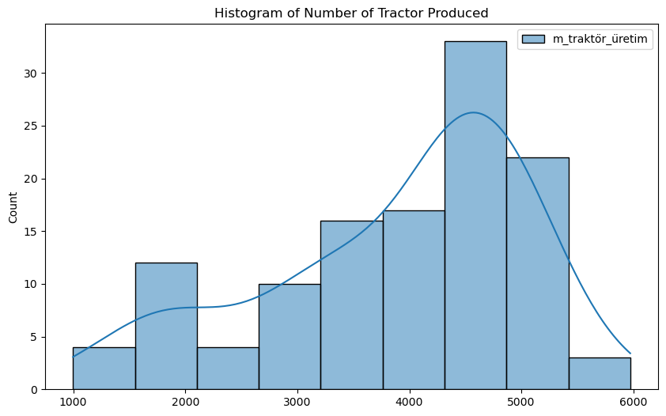

[figure not shown]

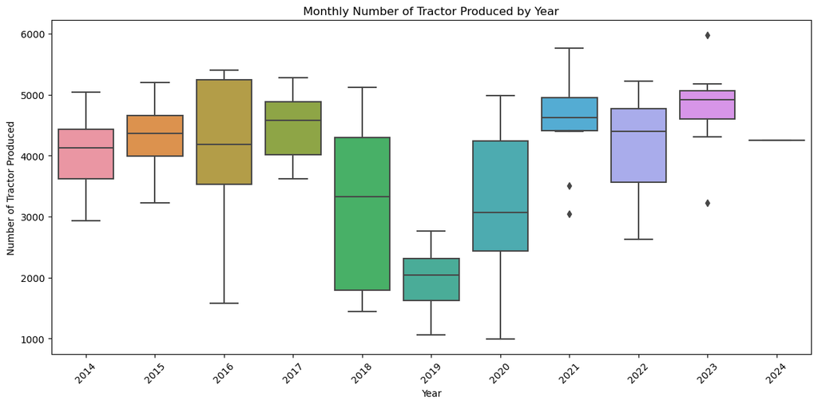

```python
plt.figure(figsize=(10, 6))
sns.histplot(data=numberoftractorproduced, kde=True)
plt.title('Histogram of Number of Tractor Produced')
plt.show()
plt.figure(figsize=(14, 7))
plt.plot(numberoftractorproduced.index, numberoftractorproduced['m_traktör_üretim'], marker='o', linestyle='-')
plt.title('Number of Tractor Produced')
plt.xlabel('Date')
plt.ylabel('Tractor Produced')
plt.xticks(rotation=45)
plt.tight_layout()
plt.show()

df1 = pd.read_excel('./ie360_hw1/m_traktör_üretim.xlsx', parse_dates=['Tarih'])

df1['Year'] = df1['Tarih'].dt.year

fig, ax = plt.subplots(figsize=(12, 6))

sns.boxplot(ax=ax, x='Year', y='m_traktör_üretim', data=df1)
ax.set_title('Monthly Number of Tractor Produced by Year')
ax.set_ylabel('Number of Tractor Produced')
ax.set_xlabel('Year')

ax.set_xticklabels(ax.get_xticklabels(), rotation=45)

plt.tight_layout()
plt.show()
```

## Time Series Analysis of Tractor Production

In the time series plot, a noticeable decline in tractor production is observed, starting from June 2018 and continuing until March 2020. The pattern exhibits a downward trend during this specific period, which could be attributed to various economic or seasonal factors affecting production.

To account for this significant change in the data, a dummy variable has been introduced to the regression model, covering the period of June 2018 to March 2020. This allows the model to differentiate the impact of this specific timeframe on the overall production numbers.

The introduction of this dummy variable aims to improve the model's accuracy and provide a clearer understanding of the factors influencing tractor production during the observed period of decline.

```python
# Adjust the date range as necessary for the specific time period
decline_start = '2018-06-01'
decline_end = '2020-03-01'

merged_data3['decline_dummy'] = ((merged_data3.index >= decline_start) & (merged_data3.index <= decline_end)).astype(int)

X = sm.add_constant(pd.concat([merged_data3[['m_tarım_kredi', 'm_binekaraçüretim','m_kamyonüretim', 'm_kamyonetüretim', 'decline_dummy']]], axis=1))

model3 = sm.OLS(y, X.astype(float)).fit()

print(model3.summary())
```

```
                            OLS Regression Results
==============================================================================
Dep. Variable:     m_traktör_üretim   R-squared:                       0.749
Model:                            OLS   Adj. R-squared:                  0.738
Method:                 Least Squares   F-statistic:                     67.89
Date:                Fri, 05 Apr 2024   Prob (F-statistic):           1.44e-32
Time:                        23:52:17   Log-Likelihood:                -935.51
No. Observations:                 120   AIC:                             1883.
Df Residuals:                     114   BIC:                             1900.
Df Model:                           5
Covariance Type:            nonrobust
=======================================================================================
                          coef    std err          t      P>|t|      [0.025      0.975]
---------------------------------------------------------------------------------------
const                1515.0547    280.698      5.397      0.000     958.995    2071.115
m_tarım_kredi       -1.525e-07   7.58e-07     -0.201      0.841   -1.65e-06    1.35e-06
m_binekaraçüretim     0.0098      0.004      2.290      0.024       0.001       0.018
m_kamyonüretim         0.2729      0.072      3.797      0.000       0.131       0.415
m_kamyonetüretim       0.0365      0.010      3.718      0.000       0.017       0.056
decline_dummy       -1796.9265    161.589    -11.120      0.000   -2117.033   -1476.820
==============================================================================
Omnibus:                        0.357   Durbin-Watson:                   1.081
Prob(Omnibus):                  0.837   Jarque-Bera (JB):                0.339
Skew:                          -0.125   Prob(JB):                        0.844
Kurtosis:                       2.926   Cond. No.                     7.33e+08
==============================================================================

Notes:
[1] Standard Errors assume that the covariance matrix of the errors is correctly specified.
[2] The condition number is large, 7.33e+08. This might indicate that there are
strong multicollinearity or other numerical problems.
```

### Regression Output Analysis

**Comparison with Previous Model**:

- The current model demonstrates an improved fit and stronger predictive capability as evidenced by a higher R-squared value compared to the initial model.
- The inclusion of `decline_dummy` provides valuable insight into specific periods impacting production.

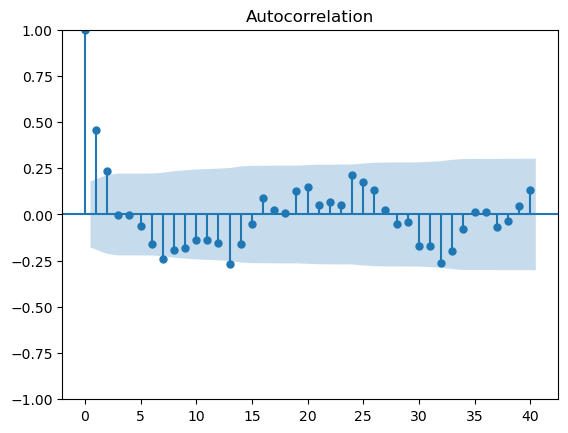

```python
from statsmodels.graphics.tsaplots import plot_acf

plot_acf(model3.resid, lags=40)
plt.show()
```

### Addressing Autocorrelation with Lagged Variable

The ACF plot showed significant autocorrelation at the first lag. To address this, I introduced a lagged dependent variable in my regression model, aiming to capture the temporal dependence and improve model accuracy.

```python
import pandas as pd
import statsmodels.api as sm
from functools import reduce


# Create a lagged variable of the dependent variable 'm_traktör_üretim'
merged_data3['lagged_y'] = merged_data3['m_traktör_üretim'].shift(1)

# Drop the first row which will have NaN for the lagged variable
merged_data3.dropna(subset=['lagged_y'], inplace=True)

# Define your dependent variable and independent variables (including the lagged variable and dummy)
X = sm.add_constant(merged_data3[['m_tarım_kredi', 'm_binekaraçüretim', 'm_kamyonüretim', 'm_kamyonetüretim', 'decline_dummy', 'lagged_y']])
y = merged_data3['m_traktör_üretim']

# Fit the model
model3 = sm.OLS(y, X.astype(float)).fit()

# Print the summary of the regression model
print(model3.summary())
```

```
                            OLS Regression Results
==============================================================================
Dep. Variable:     m_traktör_üretim   R-squared:                       0.795
Model:                            OLS   Adj. R-squared:                  0.784
Method:                 Least Squares   F-statistic:                     72.26
Date:                Fri, 05 Apr 2024   Prob (F-statistic):           3.27e-36
Time:                        23:58:54   Log-Likelihood:                -916.14
No. Observations:                 119   AIC:                             1846.
Df Residuals:                     112   BIC:                             1866.
Df Model:                           6
Covariance Type:            nonrobust
=======================================================================================
                          coef    std err          t      P>|t|      [0.025      0.975]
---------------------------------------------------------------------------------------
const                 524.1957    324.188      1.617      0.109    -118.141    1166.532
m_tarım_kredi        -3.24e-07   6.95e-07     -0.466      0.642    -1.7e-06    1.05e-06
m_binekaraçüretim     0.0105      0.004      2.692      0.008       0.003       0.018
m_kamyonüretim         0.2144      0.067      3.221      0.002       0.082       0.346
m_kamyonetüretim       0.0307      0.009      3.390      0.001       0.013       0.049
decline_dummy       -1255.2392    182.625     -6.873      0.000   -1617.086    -893.392
lagged_y                0.3111      0.062      5.010      0.000       0.188       0.434
==============================================================================
Omnibus:                        2.904   Durbin-Watson:                   1.711
Prob(Omnibus):                  0.234   Jarque-Bera (JB):                2.398
Skew:                          -0.234   Prob(JB):                        0.301
Kurtosis:                       3.514   Cond. No.                     9.64e+08
==============================================================================

Notes:
[1] Standard Errors assume that the covariance matrix of the errors is correctly specified.
[2] The condition number is large, 9.64e+08. This might indicate that there are
strong multicollinearity or other numerical problems.
```

## Improved Regression Model for Tractor Production

The final regression model exhibits an improved fit, indicated by an R-squared value of 0.795, suggesting that 79.5% of the variation in tractor production is explained by the model. The introduction of the `lagged_y` variable has significantly addressed the autocorrelation concerns, as reflected by the Durbin-Watson statistic nearing 2, which suggests minimal residual correlation. The significant negative coefficient for `decline_dummy` indicates a notable decline in tractor production during the specified period.

## Conclusions from Tractor Production Time Series Analysis

Across the three time series analyses conducted, I've gained insights into the complex dynamics of tractor production, number of house sold and worforce in Türkiye. I've identified key factors influencing production, optimized my model by incorporating lagged values and dummy variables to account for seasonality and external shocks, and have a better understanding of how past values can influence future trends. My comprehensive approach has not only improved the fit and predictive power of my models but also highlighted the importance of considering temporal dependencies and external variables in time series forecasting.